# Exercise 11.10

Kári Hlynsson

April 2024

This exercise focuses on the brain tumour data, which is included in the `ISLR2` `R` library.

## Part (a)

Plot the Kaplan-Meier survival curve with $\pm 1$ standard error bands, using the `survfit()` function in the `survival` package.

Import the data:

```r
library(ISLR2)
data(BrainCancer)
attach(BrainCancer)
```

Fit the Kaplan-Meier survival curve:

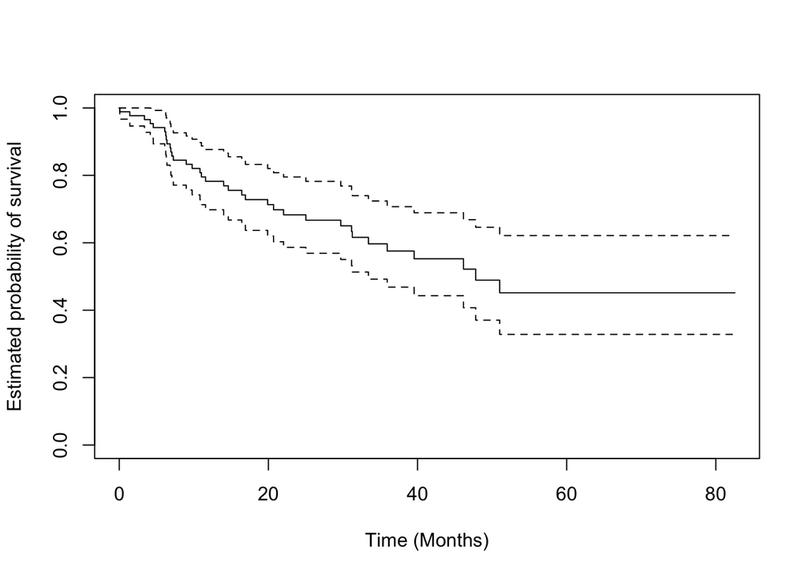

```r
library(survival)

surv_fit <- survfit(Surv(time, status) ~ 1)
plot(
  surv_fit,
  xlab = "Time (Months)",
  ylab = "Estimated probability of survival"
)
```

## Part(b)

Draw a bootstrap sample of size $n = 88$ from the pairs $(y_i, \delta_i)$, and compute the resulting Kaplan-Meier survival curve. Repeat this process $B = 200$ times. Use the results to obtain an estimate of the standard error of the Kaplan-Meier survival curve at each timepoint. Compare this to the standard errors obtained in (a).

```r
set.seed(1)

n <- 88
b <- 200

df_survfit <- data.frame()

for (i in 1:b) {
  sel <- sample(1:n, n, replace = TRUE)
  boot <- BrainCancer[sel, ]

  boot_surv <- Surv(boot$time, boot$status)
  boot_survfit <- survfit(boot_surv ~ 1)

  boot_data <- data.frame(
    time = summary(boot_survfit)$time,
    surv = summary(boot_survfit)$surv
  )

  df_survfit <- rbind(df_survfit, boot_data)
}
```

The `df_survfit` data frame contains the data we need.

```r
library(dplyr)

se_est <- df_survfit |>
  group_by(time) |>
  summarise(
    se_fit = sd(surv)
  )
```

Now let’s compare the estimates:

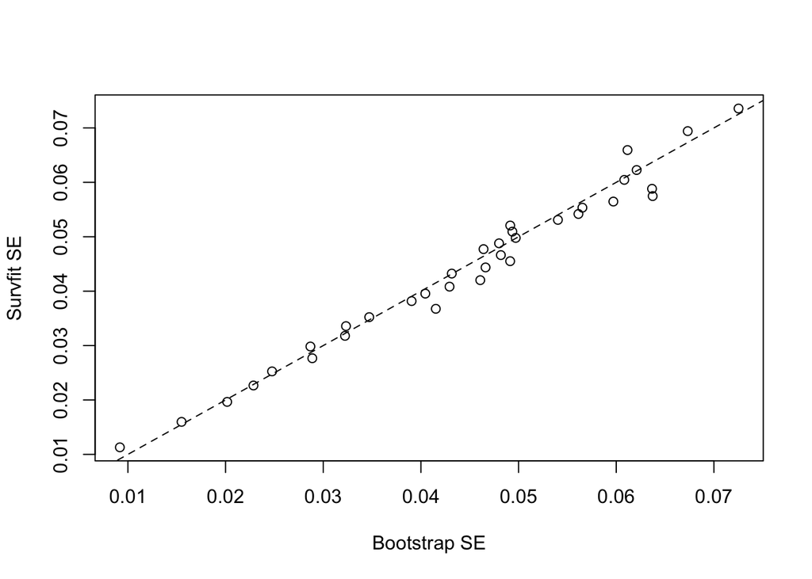

```r
se_cmp <- data.frame(
  time = se_est$time,
  se_boot = se_est$se_fit,
  se_surv = summary(surv_fit)$std.err
)

plot(
  se_cmp$se_boot,
  se_cmp$se_surv,
  xlab = "Bootstrap SE",
  ylab = "Survfit SE"
)

abline(0, 1, lty = 2)
```

They are virtually identical!

## Part (c)

Fit a Cox proportional hazards models that uses all of the predictors to predict survival. Summarise the main findings.

```r
cox_fit <- coxph(
  Surv(time, status) ~ sex + diagnosis + loc + ki + gtv + stereo
)

summary(cox_fit)
```

```
## Call:
## coxph(formula = Surv(time, status) ~ sex + diagnosis + loc +
##     ki + gtv + stereo)
##
##   n= 87, number of events= 35
##    (1 observation deleted due to missingness)
##
##                        coef exp(coef) se(coef)      z Pr(>|z|)
## sexMale             0.18375   1.20171  0.36036  0.510  0.61012
## diagnosisLG glioma  0.91502   2.49683  0.63816  1.434  0.15161
## diagnosisHG glioma  2.15457   8.62414  0.45052  4.782 1.73e-06 ***
## diagnosisOther      0.88570   2.42467  0.65787  1.346  0.17821
## locSupratentorial   0.44119   1.55456  0.70367  0.627  0.53066
## ki                 -0.05496   0.94653  0.01831 -3.001  0.00269 **
## gtv                 0.03429   1.03489  0.02233  1.536  0.12466
## stereoSRT           0.17778   1.19456  0.60158  0.296  0.76760
## ---
## Signif. codes:  0 '***' 0.001 '**' 0.01 '*' 0.05 '.' 0.1 ' ' 1
##
##                    exp(coef) exp(-coef) lower .95 upper .95
## sexMale               1.2017     0.8321    0.5930    2.4352
## diagnosisLG glioma    2.4968     0.4005    0.7148    8.7215
## diagnosisHG glioma    8.6241     0.1160    3.5664   20.8546
## diagnosisOther        2.4247     0.4124    0.6678    8.8031
## locSupratentorial     1.5546     0.6433    0.3914    6.1741
## ki                    0.9465     1.0565    0.9132    0.9811
## gtv                   1.0349     0.9663    0.9906    1.0812
## stereoSRT             1.1946     0.8371    0.3674    3.8839
##
## Concordance= 0.794  (se = 0.04 )
## Likelihood ratio test= 41.37  on 8 df,   p=2e-06
## Wald test            = 38.7  on 8 df,   p=6e-06
## Score (logrank) test = 46.59  on 8 df,   p=2e-07
```

## Part (d)

Stratify the data by the value of `ki`. (Since only one observation has `ki = 40`, you can group that observation together with the observations that `ki = 60`.) Plot Kaplan-Meier survival curves for each of the five strata, adjusted for the other predictors.

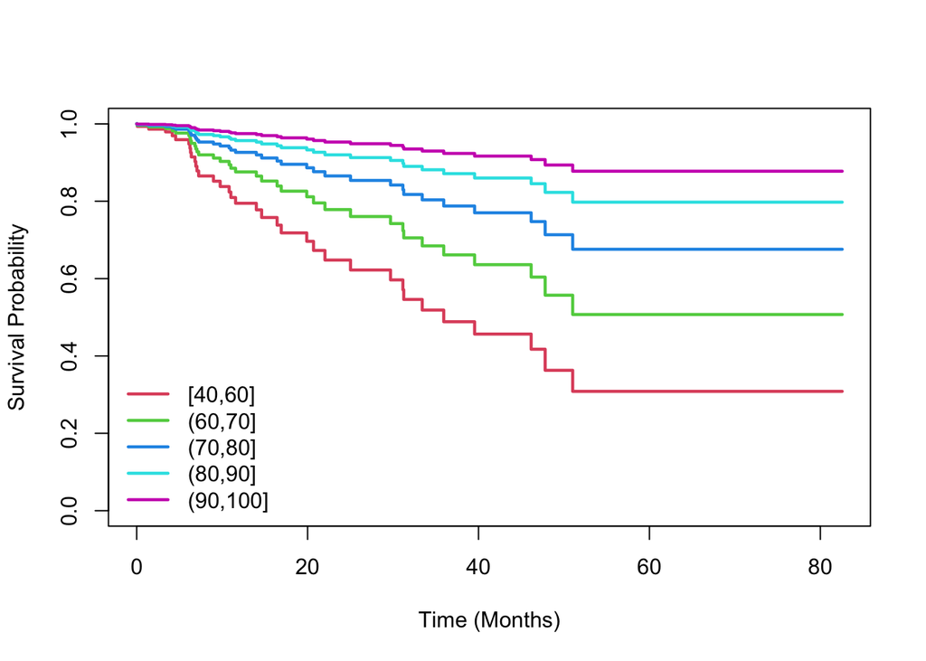

```r
modaldata <- data.frame(
  diagnosis = rep("Meningioma", 5),
  sex = rep("Female", 5),
  loc = rep("Supratentorial", 5),
  ki = c(60, 70, 80, 90, 100),
  gtv = rep(mean(gtv), 5),
  stereo = rep("SRT", 5)
)

survplots <- survfit(cox_fit, newdata = modaldata)
cut_legend <- cut(
  ki,
  breaks = seq(40, 100, by = 10)[-2],
  include.lowest = TRUE
)

plot(
  survplots,
  xlab = "Time (Months)",
  ylab = "Survival Probability",
  col = 2:6,
  lwd = 2.25
)

legend(
  "bottomleft",
  bty = "n",
  legend = levels(cut_legend),
  col = 2:6,
  lwd = 2.25
)
```